# Project 1

February 22, 2021

```r
if (!file.exists("activity.csv") )
    {
     url <- 'http://d396qusza40orc.cloudfront.net/repdata%2Fdata%2Factivity.zip'
     download.file(url,destfile='repdata%2Fdata%2Factivity.zip',mode='wb')
     unzip('repdata%2Fdata%2Factivity.zip')

}
DataSet <- read.csv("activity.csv")
summary(DataSet)
```

```
##      steps            date              interval
##  Min.   :  0.00   Length:17568       Min.   :   0.0
##  1st Qu.:  0.00   Class :character   1st Qu.: 588.8
##  Median :  0.00   Mode  :character   Median :1177.5
##  Mean   : 37.38                      Mean   :1177.5
##  3rd Qu.: 12.00                      3rd Qu.:1766.2
##  Max.   :806.00                      Max.   :2355.0
##  NA's   :2304
```

Calculate the total number of steps taken per day, and make a histogram of the total number of steps taken each day.

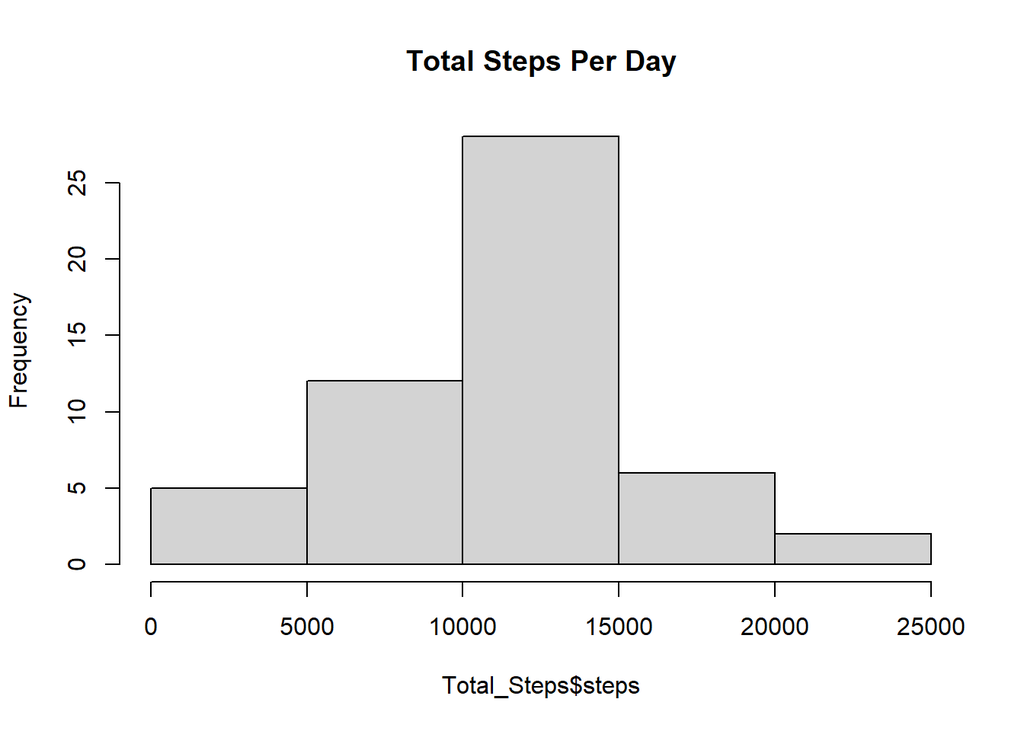

```r
Total_Steps <- aggregate(steps ~ date, DataSet, sum)
hist(Total_Steps$steps, main = paste("Total Steps Per Day"))
```

Calculate and report the mean and median of the total number of steps taken per day.

```r
Total_Steps_Mean <- mean(Total_Steps$steps)
Total_Steps_Median <- median(Total_Steps$steps)
Total_Steps_Mean
```

```
## [1] 10766.19
```

```r
Total_Steps_Median
```

```
## [1] 10765
```

Make a time series plot (i.e. type = "l") of the 5-minute interval (x-axis) and the average number of steps taken, averaged across all days (y-axis).

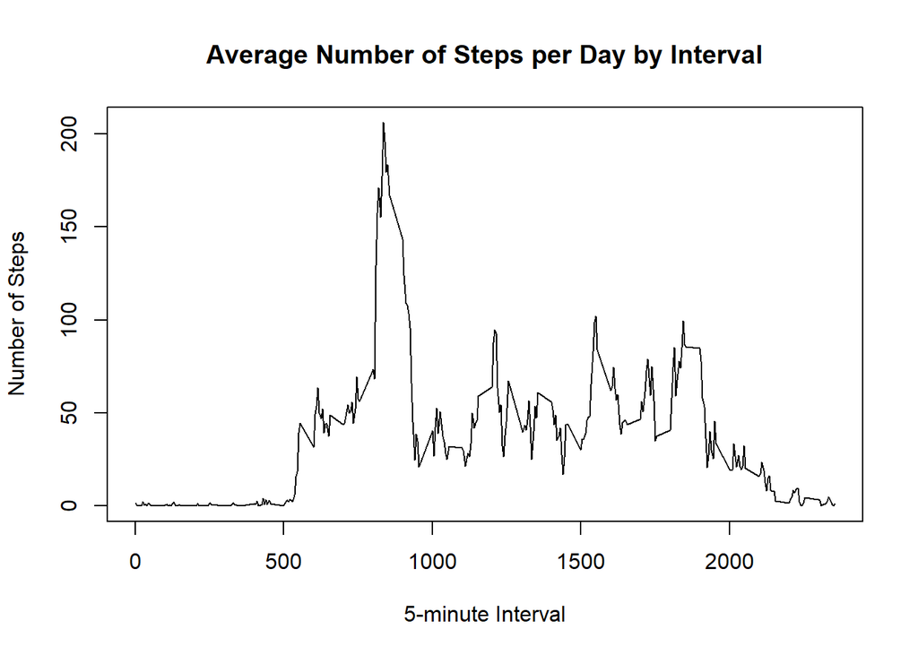

```r
Interval_Steps <- aggregate(steps ~ interval, DataSet, mean)
plot(Interval_Steps$interval,Interval_Steps$steps, type="l", xlab="5-minute Interval", ylab="Number of Steps",main="Average Number of Steps per Day by Interval")
```

Which 5-minute interval, on average across all the days in the dataset, contains the maximum number of steps?

```r
Interval_Max <- Interval_Steps[which.max(Interval_Steps$steps),1]
Interval_Max
```

```
## [1] 835
```

Calculate and report the total number of missing values in the dataset (i.e. the total number of rows with NAs)

```r
Number_NA <- sum(!complete.cases(DataSet))
Number_NA
```

```
## [1] 2304
```

```r
for(i in 1:NROW(DataSet)){
  if(is.na(DataSet[i,2])==TRUE){
    DataSet[i] = Total_Steps_Mean
  }
}
```

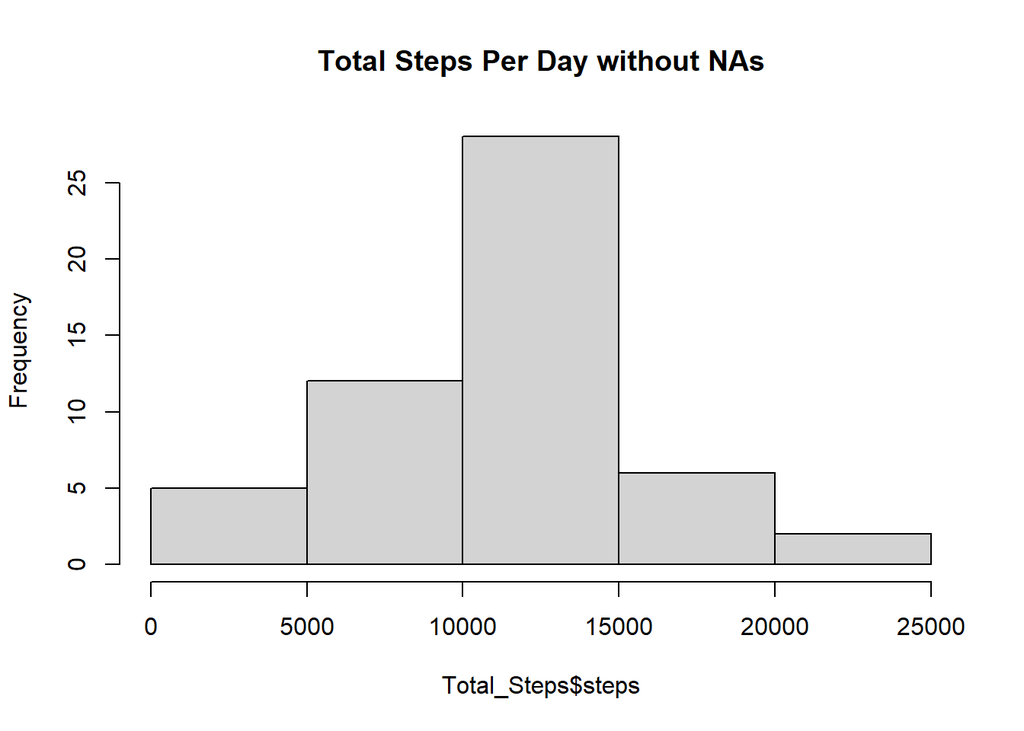

```r
Total_Steps_2 <- aggregate(steps ~ date, DataSet, sum)
hist(Total_Steps$steps, main = paste("Total Steps Per Day without NAs"))
```

```r
Total_Steps_Mean_2 <- mean(Total_Steps$steps)
Total_Steps_Median_2 <- median(Total_Steps$steps)
Total_Steps_Mean_2
```

```
## [1] 10766.19
```

```r
Total_Steps_Median_2
```

```
## [1] 10765
```

Create a new factor variable in the dataset with two levels - "weekday" and "weekend" indicating whether a given date is a weekday or weekend day. Make a panel plot containing a time series plot (i.e. type = "l") of the 5-minute interval (x-axis) and the average number of steps taken, averaged across all weekday days or weekend days (y-axis). See the README file in the GitHub repository to see an example of what this plot should look like using simulated data.

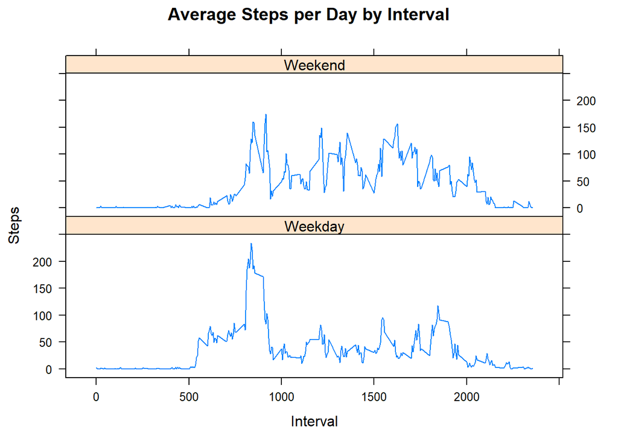

```r
weekdays <- c("Monday", "Tuesday", "Wednesday", "Thursday", "Friday")
DataSet$f = as.factor(ifelse(is.element(weekdays(as.Date(DataSet$date)),weekdays), "Weekday", "Weekend"))
Step_3 <- aggregate(steps ~ interval + f, DataSet, mean)
library(lattice)
xyplot(Step_3$steps ~ Step_3$interval|Step_3$f, main="Average Steps per Day by Interval",xlab="Interval", ylab="Steps",layout=c(1,2), type="l")
```